# Conference Report: ConectaR 2019

The ‘Conference Report: ConectaR 2019’ article from the 2019-2 issue.

Marcela Alfaro Córdoba (Universidad de Costa Rica) , Agustín Gómez Meléndez (Observatorio de Desarrollo, Universidad de Costa Rica) , Frans van Dunné (ixpantia) , Jacob van Etten (Bioversity International)  
2019-12-01

## 1 About the event

ConectaR 2019: Encuentro de Usuarios R en Latinoamérica, took place during January 24-26, 2019 at the University of Costa Rica, in San José, Costa Rica. It was the first event in Central America endorsed by The R Foundation, and it was held completely in Spanish. The majority of the attendants were from Costa Rica (85%), but we had participants from 12 countries: Costa Rica, Guatemala, Peru, Colombia, Mexico, Argentina, Uruguay, Chile, Spain, the Netherlands, France and the USA. The three-day event consisted of talks, workshops, and poster sessions.

The primary purpose of ConectaR conference was to provide a space to create a community among R users in industry, academia, citizen science and teaching. In this way, we aim to encourage the use of R, promote learning and advance the development of R packages adapted to our regional needs.

ConectaR 2019 was organized by the University of Costa Rica -through the School of Statistics, the Development Observatory, and the Research Center for Pure and Applied Mathematics- the company ixpantia, and the research institution Bioversity International. The initiative originated thanks to the encouragement of Heather Turner, who contacted several networks in the region, through the R Users Groups, R-ladies groups and other connections.

From the 150 registered participants, $33\%$ were female and $23\%$ were full time students. Professionals from finance, government and data companies were present, as well as faculty members from all four major universities in the country. The event was possible thanks to the effort of a team of about 50 people including 4 chairs, a 23-member scientific committee and a motivated group of 23 volunteers.

[figure not shown]

Figure 1: The logo of ConectaR.

## 2 Conference program

The first two days of the conference were dedicated to talks (invited and contributed) and poster presentations. On the third day of the event (a Saturday) four workshops ran in parallel: two during the morning and two during the afternoon.

[figure not shown]

Figure 2: Picture from the event.

The event had four invited talks: two that were in person and two via video conference. Edgar Ruiz from RStudio, was the first keynote. He gave a remarkably clear explanation about how to use R and Spark for Data Science. During the afternoon, Maëlle Salmon from rOpenSci and Locke Data, presented the second keynote (remote), where she talked about the ROpenSci initiative (https://ropensci.org/), and about her experience curating R packages. She gave the audience tips on how to write R packages, a clear explanation on the importance of citing, curating and recognizing R packages as part of the scientific process.

During the second day of the event, Robert Hijmans from UC Davis, explained the use of R for spatial data science, and talked about his experience using R for scientific production and teaching, including the creation of new packages. His talk ended with an invitation to translate the material from his web page into Spanish: https://rspatial.org/. To close the last day of talks, Antonio Vasquez Brust from Buenos Aires University (UBA), Argentina gave a detailed description on how to use R and Open Data to understand our cities. His discussion encouraged good practices in visualization as well as a conversation about city planning using R when Open Data is available.

A panel named “Connecting data innovation initiatives in Latin America with R” was facilitated by Diego May (ixpantia) during the second day of the event. The intention of the panel was to have professionals talk about the opportunities and challenges around the use of R in their different work contexts. Alexia Pacheco of ICE, the largest utility company in Costa Rica, explained how data science and R has pervaded their work since its origin. Jacob van Etten (Bioversity International) explained how R is used in a multi-country team in an international agricultural research institute. It has provided important opportunities for quick methodological innovation to support a large citizen science initiative. Alvaro Pabón of Finsocial Colombia, explained how he has set up a data science team in a Colombian company, the challenges to build this capacity and the support needed for it.

Eleven contributed talks and fourteen posters were presented during the event. The selection process had two stages: during the first one, the reviewers gave recommendations to the authors on how to improve their abstract, and during the second stage, the talks that had a satisfactory level were accepted. The posters were then reviewed by the chairs to ensure all of them had a satisfactory level. Two out of the eleven contributed talks and six out of the fourteen posters were presented by women.

The topics of the contributed talks followed the four themes of the conference. First government and citizen science, where we saw how shiny apps are used at the Costa Rican national comptroller’s office. We also heard how the national statistics office is transitioning from SPSS to R. In the industry track a talk about the transition from Excel to R at the national insurance institute showed how this has lead to significant reduction in time spent on data processing. In academia the visualization and analysis of complex climate data took center stage in two separate talks. The teaching track included a fun example of how to predict the outcome of soccer matches, and showcased experiences from Mexico of the power of R as a didactic tool in statistics and mathematics.

After the last break of the first day, the poster session was opened and accompanied by the conference cocktail reception. As organizers we felt strongly about including sufficient opportunities for people to mingle and talk. The posters were well visited and led to spirited discussions. The conference dinner had a lower attendance than the reception, but served its purpose just as well in offering an opportunity for people in the community to connect and re-connect.

During the last day of the event four workshops were held, each of which managed to attract full classrooms:

- Crear API’s con código R usando plumber by Frans van Dunné.
- Documentos dinámicos, trabajo colaborativo y control de versiones con Rmarkdown y GitHub by Natalia da Silva.
- Análisis de texto by Riva Quiroga.
- Introducción al análisis Bayesiano con aplicaciones en STAN by Ignacio Álvarez-Castro.

ConectaR served to connect different communities, announce exciting projects and to create new ones. Examples are the visit and help of two of the three chairs of LatinR to teach workshops and their LatinR2019 announcement during the closing remarks of ConectaR. Also, Riva Quiroga explained details about the R4DS translation project (https://es.r4ds.hadley.nz) to the community, and Frans van Dunné asked for volunteers to start the (already advanced) Plumber translation project (https://github.com/fontanero-api/).

Communities outside R were also involved, such as Women in Engineering, who organized an introduction to R workshop for its members two months after the event, with the help of Marcela Alfaro Córdoba. DataLatam did several interviews for their [podcast](https://www.datalatam.com) thanks to the connections established during ConectaR, and the School of Statistics made the first arrangements to invite Edgar Ruiz to give a week of workshops to its students and faculty in June.

## 3 Evaluation

An evaluation questionnaire was circulated after the event, and $70\%$ of the participants filled it out. The results were overwhelmingly positive, having a median rate of 5 (on a scale from 1=bad job to 5=good job) for all the questions, with very small variability in each distribution. A word cloud of the comment section of the questionnaire was constructed and is shown in Figure 3, where it is clear that positive words such as excellent (excelente), good (bien, bueno) and quality (calidad) were among the most used in the comments.

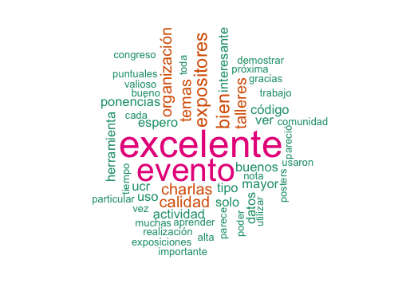

Figure 3: Word cloud for the evaluation comments.

## 4 Corporate Sponsors

ConectaR was possible thanks to the main sponsors: INCAE Business School, R Consortium, RStudio, Inc., Hivos Latinoamerica, The Trust for the Americas. Also, a small job fair was organized parallel to the conference, in which the some of the main sponsors participated, along with companies like McKinsey $\&$ Company, Alteryx, Growth Acceleration and Partners, ThermoFisher Scientific and ixpantia.

## 5 Other Events and Future Steps

Future plans for the chairs of ConectaR include ConectaR 2021, where the expectation is to improve the network with communities in Mexico, Colombia, Panamá, and search for funding sources to overcome our most important limitation for this edition: lack of funding to cover travel expenses. Also, the organization of more local events such as a Datathon for 2020, is on the agenda. The idea is to gather momentum to get different R communities from the region to participate in a visualization competition, inspired in Open Data from the Costa Rican Government.

## 6 Further information

- ConectaR materials: https://github.com/ConectaR2019.
- Twitter account: [@conecta_R](http://www.twitter.com/conecta_R), [#ConectaR2019](https://twitter.com/hashtag/ConectaR2019?src=hash).
- Webpage: http://www.conectar2019.ucr.ac.cr
- Facebook account: [conectar2019](https://www.facebook.com/conectar2019/)